# 05_Search_in_Graphs

## Пошук в графах.

**Depth First Search (DFS)** (Обхід/пошук у глибину) — алгоритм обходу для графа/дерева, який заглиблюється в кожну гілку, перш ніж переходити до іншої гілки. Обхід із встановленням вершини через змінну. Реалізація використовує подання списку суміжності графів.

Мета алгоритму - позначити кожну вершину, уникаючи циклів (подвійне відвідування вершини).

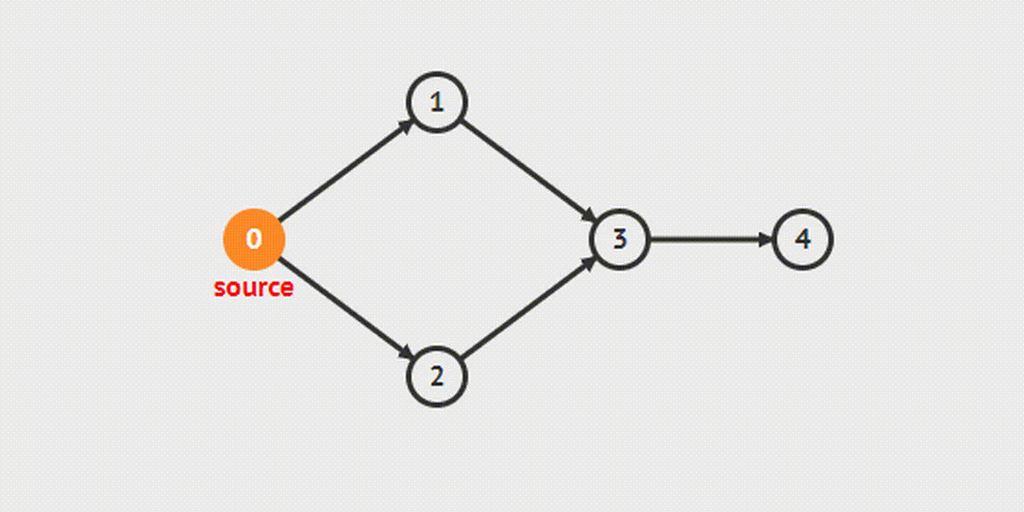

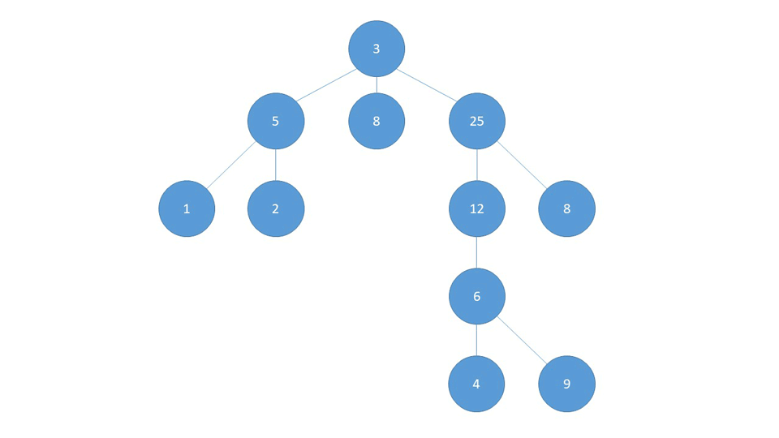

**Типи алгоритмів обходу дерева у глибину (DFS)**

**Обхід у прямому порядку** (Preorder Traversal). Спочатку обходимо корінь, потім ліве та праве піддерева.

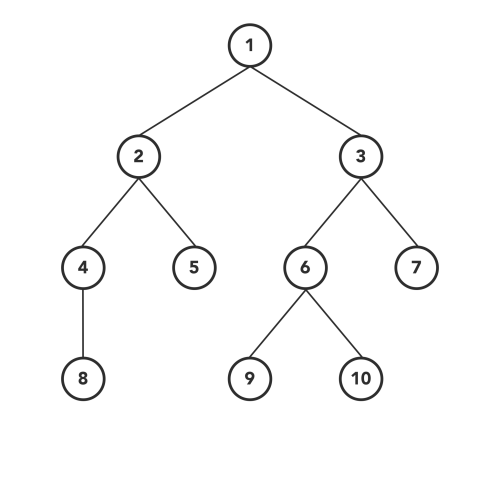

**Обхід у центрованому порядку** (Inorder Traversal). Для центрованого обходу спочатку обходимо ліве піддерево, потім корінь, а потім праве піддерево.

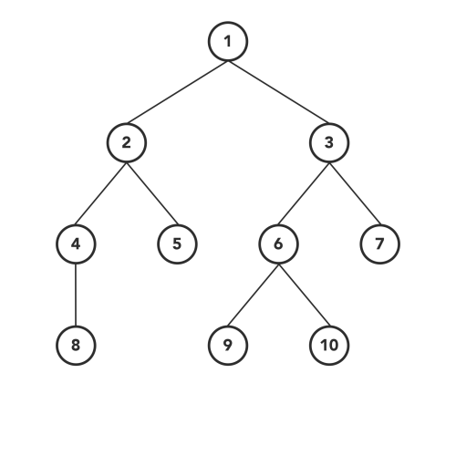

**Обхід у зворотньому порядку** (Postorder Traversal). У зворотньому порядку обходимо ліве та праве піддерево перед обходом кореня.

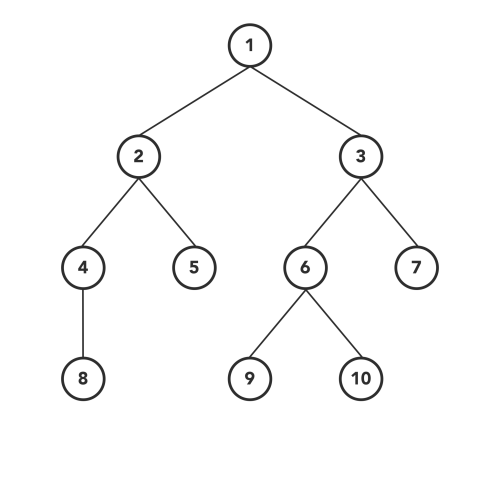

**Breadth First Search (BFS)** (Обхід/пошук у ширину) — алгоритм обходу, який дозволяє шукати вузол у графі/дереві, подорожуючи їх вузлами вшир. Обхід із встановленням вершини через змінну. Реалізація використовує подання списку суміжності графів.

Основний підхід алгоритму пошуку в ширину (BFS) полягає в пошуку вузла в структурі дерева або графа шляхом дослідження сусідів перед дочірніми елементами.

Мета алгоритму - позначити кожну вершину, уникаючи циклів (подвійне відвідування вершини).

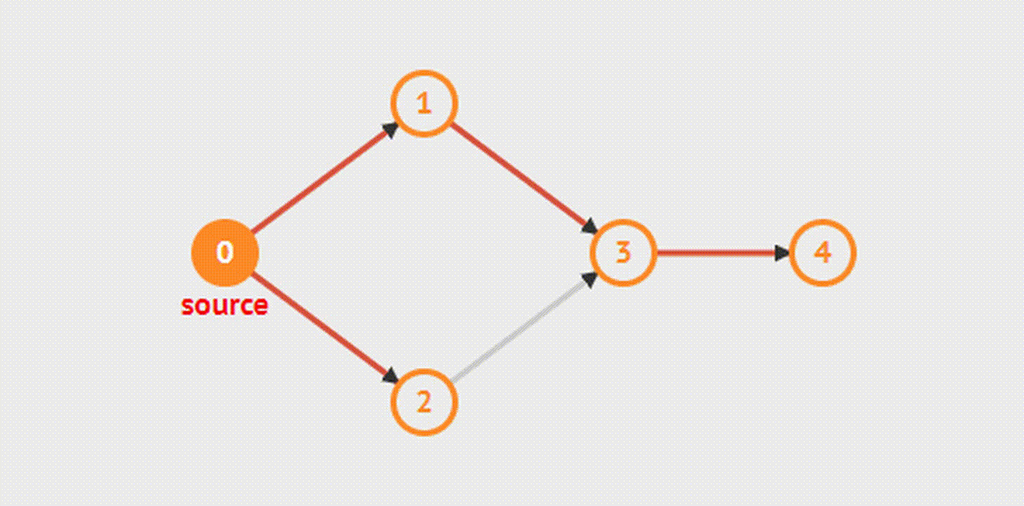

**Обхід у порядку рівнів** (Level Order Traversal) відповідає пошуку у ширину (BFS), щоб відвідати кожен вузол дерева.

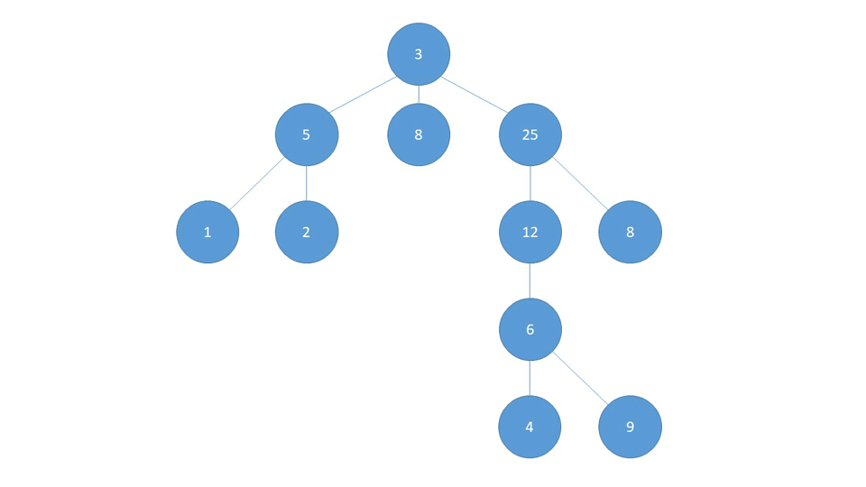

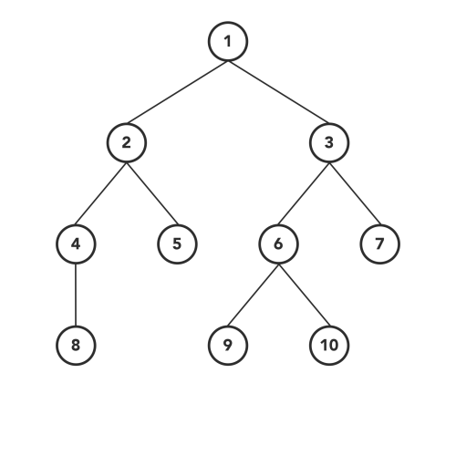